# Analysis: Pancreatic Cell Loadings

Ziang Zhang

## Data and analysis question

We analyze semi-NMF loading factors from pancreatic cells. We sample at most 500 cells per cell type with seed 1, retain cells measured with `inDrop3`, and select factor columns 3, 8, 9, 12, 17, 18, 20, and 21. This gives **865 cells by 8 factors**. We fit $M=1$ and $M=2$ MPCurve models to the same matrix to see what each specified number of orderings captures.

## Fitting settings

Table 1 lists the settings. Both fits use MPCurver 0.3.4, CAVI, an RW2 trajectory prior, $K=50$ grid positions, and `ridge = 0`. The $M=1$ fit starts from PCA; the $M=2$ fit applies Fiedler ordering independently to both similarity-based feature groups. Exact seeds and iteration budgets are in the [reproduction script](https://github.com/AgueroZZ/InferOrder/blob/master/experiments/mpcurve_v034_site/run_pancreas.R).

Table 1. Fixed model and initialization settings.

| model | seed | method | K | rw_q | ridge | max_converge_iter |
| --- | --- | --- | --- | --- | --- | --- |
| M1 | 20260925 | PCA | 50 | 2 | 0 | NA |
| M2 | 20260927 | fiedler | 50 | 2 | 0 | 500 |

## One versus two orderings

Figure 1 arranges the same loadings according to each fitted sample ordering. The first panel uses $M=1$; the other two are orderings A and B from the fixed $M=2$ fit. Colours show the observed loading values, with the same colour scale in all panels. Ordering direction is arbitrary.

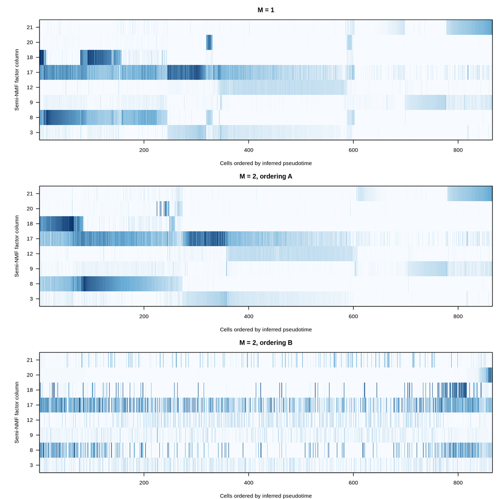

Figure 1. Eight semi-NMF loading factors arranged by the inferred cell positions under fixed M = 1 and M = 2 fits.

The absolute Spearman correlations between the $M=1$ positions and the $M=2$ positions are **0.968** for ordering A and **0.058** for ordering B. Ordering A closely follows the single-ordering fit; ordering B places cells differently.

Cell-type annotations provide another view of the fitted positions. Each point in Figure 2 is one cell, grouped by its recorded cell type.

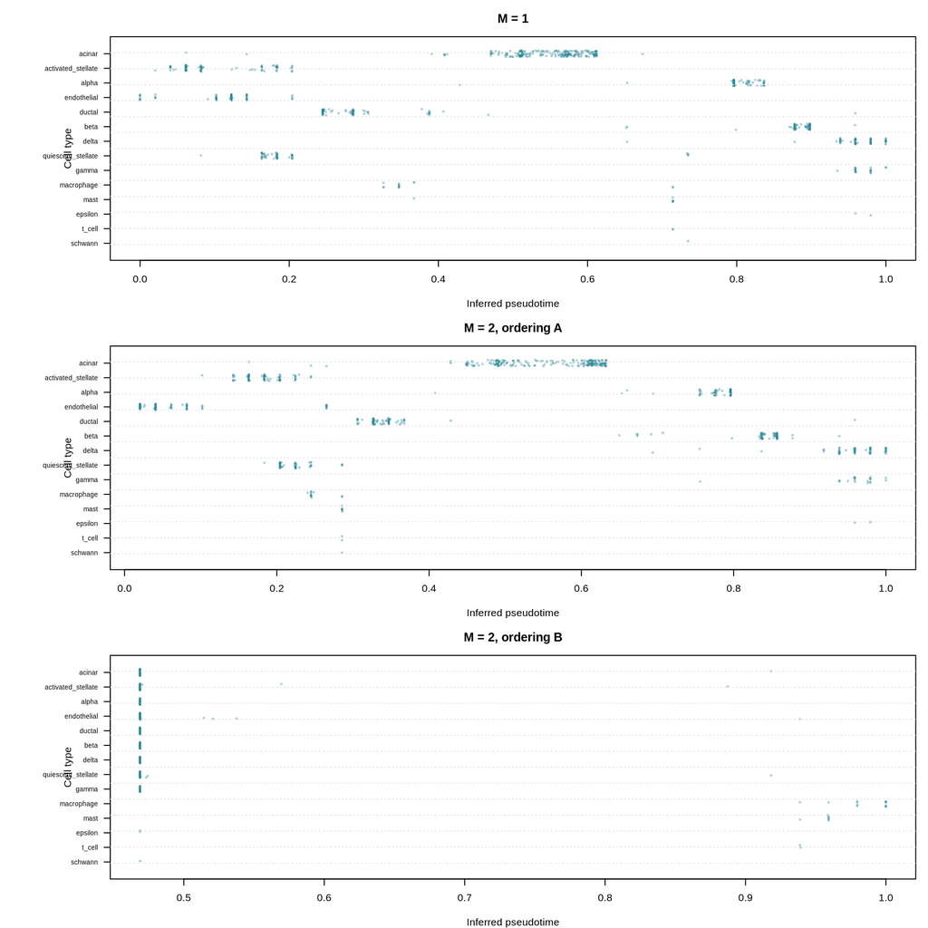

Figure 2. Inferred pseudotime for each pancreatic cell, grouped by the recorded cell type.

## Feature assignments in the two-ordering fit

Table 2. Posterior ordering probabilities for each selected semi-NMF factor.

| factor | ordering_A | ordering_B | assignment |
| --- | --- | --- | --- |
| Factor 3 | 1 | 0 | A |
| Factor 8 | 1 | 0 | A |
| Factor 9 | 1 | 0 | A |
| Factor 12 | 1 | 0 | A |
| Factor 17 | 1 | 0 | A |
| Factor 18 | 1 | 0 | A |
| Factor 20 | 0 | 1 | B |
| Factor 21 | 1 | 0 | A |

Seven factors follow ordering A; only factor 20 follows B (Table 2). Most cells have similar fitted positions on B, while a smaller subset spreads across its range. The second ordering is therefore driven mainly by factor 20 in this fit.

## Fitting objectives

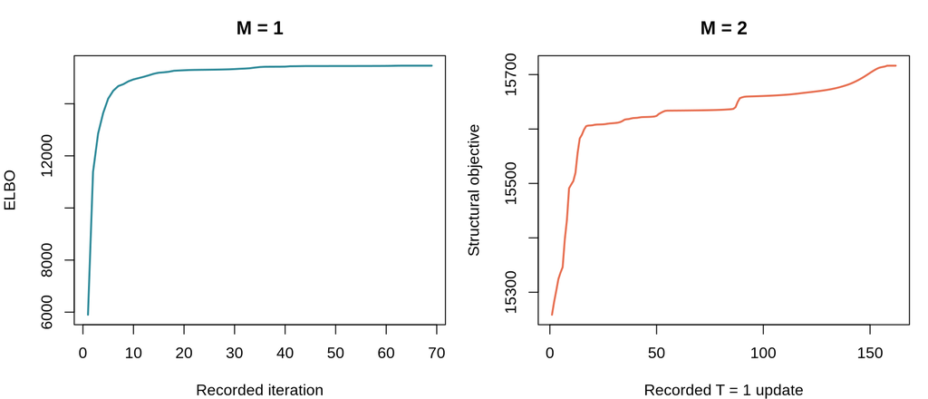

Figure 3. Within-model objectives: the M = 1 CAVI ELBO and the M = 2 structural objective at T = 1.

Each objective rises during its own fit (Figure 3), and both fits satisfy the normalized per-observation convergence rule. The two panels use different objectives, so their heights cannot be used to choose $M$.

## Reproduce

The [reproduction script](https://github.com/AgueroZZ/InferOrder/blob/master/experiments/mpcurve_v034_site/run_pancreas.R) reconstructs the input matrix and both fits. The [saved results](https://github.com/AgueroZZ/InferOrder/tree/master/experiments/mpcurve_v034_site/results/pancreas) include selected cell IDs, fit settings, assignments, and fitted positions.